# Project 2: Data Mining, Classification, Prediction

SDS322E

# Mining, Classification, Prediction

## Andie Brown, ajb5656

### Introduction

```r
library(tidyverse)
# read your datasets in here, e.g., with read_csv()
baseball_data <- read_csv("https://vincentarelbundock.github.io/Rdatasets/csv/vcd/Baseball.csv")
head(baseball_data)
```

```
## # A tibble: 6 x 26
##      X1 name1 name2 atbat86 hits86 homer86 runs86 rbi86 walks86 years atbat
##   <dbl> <chr> <chr>   <dbl>  <dbl>   <dbl>  <dbl> <dbl>   <dbl> <dbl> <dbl>
## 1     1 Al    Newm…     185     37       1     23     8      21     2   214
## 2     2 Alan  Ashby     315     81       7     24    38      39    14  3449
## 3     3 Alan  Tram…     574    159      21    107    75      59    10  4631
## 4     4 Alan  Wigg…     239     60       0     30    11      22     6  1941
## 5     5 Alex  Trev…     202     53       4     31    26      27     9  1876
## 6     6 Alfr… Grif…     594    169       4     74    51      35    11  4408
## # … with 15 more variables: hits <dbl>, homeruns <dbl>, runs <dbl>, rbi <dbl>,
## #   walks <dbl>, league86 <chr>, div86 <chr>, team86 <chr>, posit86 <chr>,
## #   outs86 <dbl>, assist86 <dbl>, error86 <dbl>, sal87 <dbl>, league87 <chr>,
## #   team87 <chr>
```

```r
# if your dataset needs tidying, do so here

# any other code here
baseball_data %>% count(league86)
```

```
## # A tibble: 2 x 2
##   league86     n
##   <chr>    <int>
## 1 A          175
## 2 N          147
```

```r
baseball_data %>% count(league87)
```

```
## # A tibble: 2 x 2
##   league87     n
##   <chr>    <int>
## 1 A          176
## 2 N          146
```

```r
baseball_data %>% count(div86)
```

```
## # A tibble: 2 x 2
##   div86     n
##   <chr> <int>
## 1 E       157
## 2 W       165
```

### Cluster Analysis

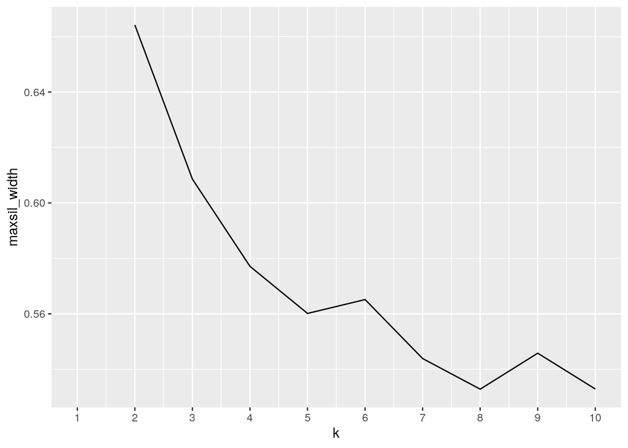

```r
library(cluster)
# clustering code here
library(GGally)
bball_data <- baseball_data %>% select(years, atbat, hits, homeruns,
    runs)
bball_data <- bball_data %>% drop_na()
maxsil_width <- vector()
for (i in 2:10) {
    kms <- kmeans(bball_data, centers = i)
    sil <- silhouette(kms$cluster, dist(bball_data))
    maxsil_width[i] <- mean(sil[, 3])
}
ggplot() + geom_line(aes(x = 1:10, y = maxsil_width)) + scale_x_continuous(name = "k",
    breaks = 1:10)
```

```r
pam1 <- bball_data %>% pam(k = 2)
pam1
```

```
## Medoids:
##      ID years atbat hits homeruns runs
## [1,] 93     4  1064  290       11  123
## [2,] 54    12  5150 1429      166  747
## Clustering vector:
##   [1] 1 2 2 1 1 2 1 2 2 1 1 1 1 1 1 2 2 2 1 2 2 1 1 1 1 1 1 1 1 1 1 2 1 1 1 2 1
##  [38] 1 2 1 2 1 2 1 2 2 1 2 1 1 2 2 2 2 1 1 1 2 1 1 2 1 1 2 1 2 1 1 1 1 1 1 2 2
##  [75] 1 1 1 1 1 2 2 1 2 2 2 2 1 1 1 2 1 1 1 1 2 2 2 1 1 2
##  [ reached getOption("max.print") -- omitted 222 entries ]
## Objective function:
##    build     swap
## 1121.744 1007.281
##
## Available components:
##  [1] "medoids"    "id.med"     "clustering" "objective"  "isolation"
##  [6] "clusinfo"   "silinfo"    "diss"       "call"       "data"
```

```r
pam1$silinfo$avg.width
```

```
## [1] 0.6433698
```

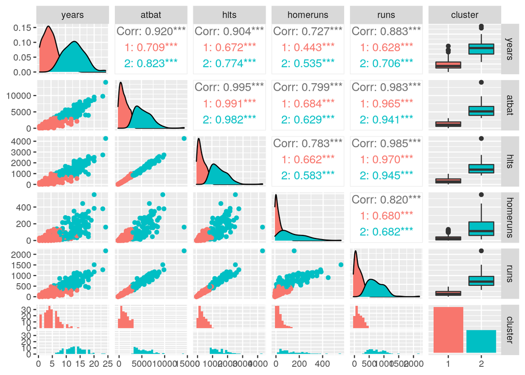

```r
bball_data %>% mutate(cluster = as.factor(pam1$clustering)) %>%
    ggpairs(cols = 1:6, aes(color = cluster))
```

### Dimensionality Reduction with PCA

```r
# PCA code here
pca1 <- princomp(bball_data, cor = T)
summary(pca1, loadings = "T")
```

```
## Importance of components:
##                           Comp.1    Comp.2     Comp.3      Comp.4       Comp.5
## Standard deviation     2.1285416 0.5606572 0.36910602 0.122494377 0.0610731916
## Proportion of Variance 0.9061379 0.0628673 0.02724785 0.003000974 0.0007459869
## Cumulative Proportion  0.9061379 0.9690052 0.99625304 0.999254013 1.0000000000
##
## Loadings:
##          Comp.1 Comp.2 Comp.3 Comp.4 Comp.5
## years     0.439  0.346  0.817  0.127
## atbat     0.465  0.181 -0.200 -0.423 -0.729
## hits      0.462  0.208 -0.327 -0.419  0.679
## homeruns  0.405 -0.894  0.170
## runs      0.462        -0.396  0.790
```

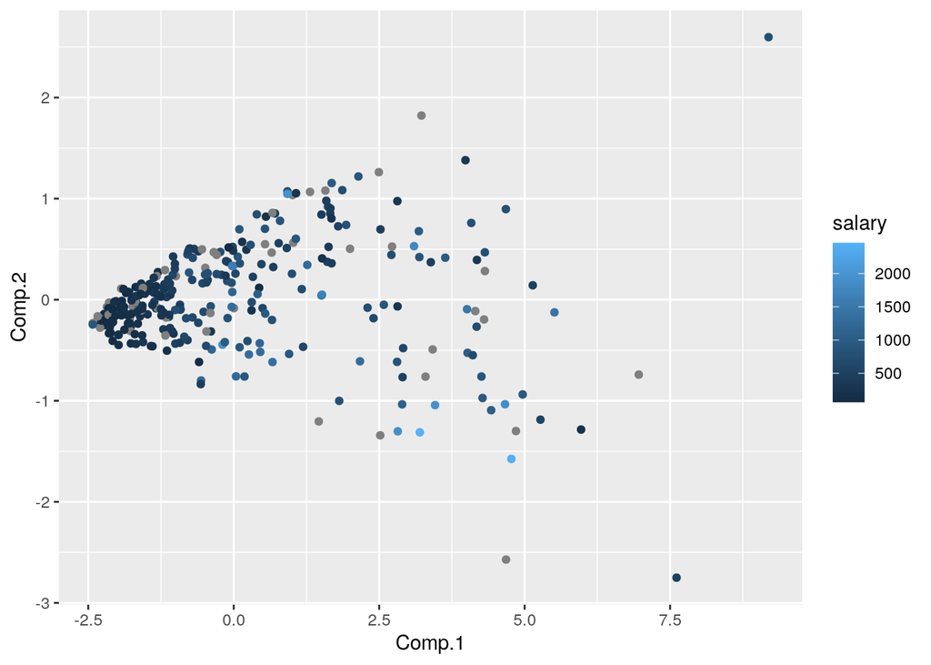

```r
pcmatcor <- pca1$scores
results <- pcmatcor %>% as.data.frame %>% mutate(salary = baseball_data$sal87)
results %>% ggplot(aes(Comp.1, Comp.2)) + geom_point(aes(color = salary))
```

*Here a ggplot was created in which PC2 is plotted against PC1, and the data points, which represent the different baseball players in the dataset, are color coded based on the salary they earned in 1987. For PC1, the loadings are very similar in value and are positive. This means that scoring high on PC1 means that those players have higher values for career years, times at bat, times hitting the ball, homeruns, and runs. Scoring low on PC1 would indicate that a player has lower values for those variables. PC2 represents a years, atbat, and hits vs. homeruns axis. Thus scoring high on PC2 means high values for career years, times at bat, and times hitting the ball, but low values for homeruns. Conversely, scoring low on PC2 means low values for career years, times at bat, and times hitting the ball, but high values for homeruns. Furthermore, almost all of the total variance can be explained by PC1, as it can explain 90.6% of the total variance. When PC1 and PC2 are included together, then 96.9% of the total variance is explained.*

### Linear Classifier

```r
# linear classifier code here
baseball <- baseball_data %>% drop_na()
baseball <- baseball %>% mutate(div86 = ifelse(div86 == "E",
    1, 0))
l_fit <- glm(div86 ~ atbat86 + hits86 + homer86 + runs86 + rbi86 +
    walks86 + years + atbat + hits + homeruns, data = baseball,
    family = "binomial")
probs <- predict(l_fit, type = "response")
class_diag(probs, baseball$div86, positive = "1")
```

```
##            acc   sens   spec    ppv    f1    ba    auc
## Metrics 0.5741 0.5116 0.6343 0.5739 0.541 0.573 0.6067
```

```r
table(truth = baseball$div86, predictions = probs > 0.5)
```

```
##      predictions
## truth FALSE TRUE
##     0    85   49
##     1    63   66
```

```r
# cross-validation of linear classifier here
set.seed(322)
k = 10

data <- sample_frac(baseball)
folds <- rep(1:k, length.out = nrow(data))

diags <- NULL

i = 1
for (i in 1:k) {
    train <- data[folds != i, ]
    test <- data[folds == i, ]
    truth <- test$div86


    new_fit <- glm(div86 ~ atbat86 + hits86 + homer86 + runs86 +
        rbi86 + walks86 + years + atbat + hits + homeruns, data = baseball,
        family = "binomial")

    new_probs <- predict(new_fit, newdata = test, type = "response")

    diags <- rbind(diags, class_diag(new_probs, truth, positive = "1"))
}

summarize_all(diags, mean)
```

```
##       acc   sens    spec     ppv      f1     ba     auc
## 1 0.57378 0.5117 0.62934 0.58007 0.53453 0.5705 0.61091
```

*The binary variable being evaluated here is div86, which represents the baseball division in 1986. The two values are either the east division or the west division. Mutate was used so that the east division was represented as 1 and represents the positive cases, while the west division is indicated by a 0 and represents the negative cases.Using a linear classifier, there was an AUC value of 0.6067, which means that this model is performing poorly. Additionally, a confusion matrix was created and showed that the true negative rate was 0.634, which was higher than the true positive rate, which was determined to be 0.511. Which means that the model is worse at correctly predicting positive cases for div86. Specifically, the model is worse at correctly predicting an east division and is better at predicting a correct west division player. Futhermore, a cross validation was performed and resulted in a slightly increased AUC value of 0.61091. This means that model is poor at predicting new observations per CV AUC. While this AUC value is still not too good, the increase in the value means that the model does not show signs of overfitting.*

### Non-Parametric Classifier

```r
library(caret)
# non-parametric classifier code here
kfit <- knn3(div86 ~ atbat86 + hits86 + homer86 + runs86 + rbi86 +
    walks86 + years + atbat + hits + homeruns, data = baseball)
kprobs <- predict(kfit, newdata = baseball)[, 2]
class_diag(kprobs, baseball$div86, positive = "1")
```

```
##            acc   sens   spec    ppv     f1     ba    auc
## Metrics 0.7148 0.7132 0.7164 0.7077 0.7104 0.7148 0.7745
```

```r
table(truth = baseball$div86, predictions = kprobs > 0.5)
```

```
##      predictions
## truth FALSE TRUE
##     0    96   38
##     1    37   92
```

```r
# cross-validation of non-parametric classifier here
set.seed(322)
k = 10

bdata <- sample_frac(baseball)
bfolds <- rep(1:k, length.out = nrow(bdata))

diags <- NULL

i = 1
for (i in 1:k) {
    train <- bdata[folds != i, ]
    test <- bdata[folds == i, ]
    truth <- test$div86

    fit <- knn3(div86 == "1" ~ atbat86 + hits86 + homer86 + runs86 +
        rbi86 + walks86 + years + atbat + hits + homeruns, data = baseball)

    bprobs <- predict(fit, newdata = test)[, 2]

    diags <- rbind(diags, class_diag(bprobs, truth, positive = "1"))
}

summarize_all(diags, mean)
```

```
##       acc    sens    spec     ppv  f1      ba     auc
## 1 0.71566 0.71113 0.71364 0.69777 0.7 0.71239 0.77584
```

*For the non-parametric classifier, there is an AUC value of 0.7745, which means that this model is performing fair. A confusion matrix was created and from that, the true negative rate was determined to be 0.716 and the true positive rate was determined to be 0.713. In this case, the model is much better at correctly predicting an east or west division compared to the linear classification model. Additionally, the TPR and the TNR are very similar and are somewhat high, which means that this model is fairly good at correctly predicting both a positive case (an east division) and a negative case (a west division). Furthermore, after performing a cross-validation, the AUC value slightly increased to 0.77584. This means that there are no signs of overfitting and that the model is good at predicting new observations per CV AUC. Lastly, the non-parametric model has a much higher cross-validation performance than the linear model, as the non-parametric model has an AUC value of 0.77584 compared to the linear model’s AUC value of 0.61091.*

### Regression/Numeric Prediction

```r
# regression model code here
refit <- lm(homer86 ~ atbat86 + hits86, data = baseball)
yhat <- predict(refit)
mean((baseball$homer86 - yhat)^2)
```

```
## [1] 52.8334
```

```r
# cross-validation of regression model here
set.seed(322)
k = 5
rdata <- baseball[sample(nrow(baseball)), ]
rfolds <- cut(seq(1:nrow(baseball)), breaks = k, labels = F)

diags <- NULL
for (i in 1:k) {
    rtrain <- rdata[folds != i, ]
    rtest <- rdata[folds == i, ]

    rfit <- lm(homer86 ~ atbat86 + hits86, data = baseball)
    ryhat <- predict(rfit, newdata = rtest)

    diags <- mean((rtest$homer86 - ryhat)^2)
}
mean(diags)
```

```
## [1] 58.58645
```

*A linear regression model was used in order to predict the numeric variable ‘homer86’ from the two predictor variables: atbat86 and hits86. In other words, a linear regression model was created in order to predict the number of homeruns a player had in 1986 from the amount of times they were up to bat and the amount of times they hit the ball when pitched to them in the same year. The mean squared error was determined to be 52.8334, which is quite high but was the smallest MSE when other numeric variables for this dataset were predicted. Furthermore, a cross validation was performed and resulted in a MSE value of 58.58645. Since the MSE value increased, it means that there are signs of overfitting, which is not good.*

### Python

```r
library(reticulate)
use_python("/usr/bin/python3")
AB <- "Merry"
```

```python
# python code here
AB="Christmas"
print(r.AB,AB)
```

```
## Merry Christmas
```

```r
cat(c(AB, py$AB))
```

```
## Merry Christmas
```

*In R, AB was defined to be the word Merry, and in python it was defined to be the word Christmas.In both R and python, the two objects were ran together to compute the phrase “Merry Christmas.” When doing this in python, the r. must be used in order to access the R defined object AB, and when doing this in R, $py must be used in order to access the python defined object AB.*

### Concluding Remarks

*Thank you for a great semester!*